```r
library(car)
placekick <- read.table( file = "./Placekick.csv" , header = TRUE , sep = ",")
```

# Interactions and transformations for explanatory variables

### Interactions

Interactions between explanatory variables are needed when the effect of one explanatory variable on the probability of success depends on the value for a second explanatory variable.

Ex: logit($\large \pi$) = $\large \beta_0 + \beta_1x_1 + \beta_2x_2 + \beta_3x_1x_2$

We change the **formula** argument in **glm()** to do so. Equivalent ways to code the model are:

1. formula = y ~ x1 + x2 + x1:x2 #colon denotes interaction between x1 and x2
2. formula = y ~ x1*x2 # asterisk automatically creates main effects (x1 and x2 by themselves) and interaction
3. formula = y ~ (x1 + x2)^2 # creates combinations of all variables

### Transformations

An example is when the relationship between an explanatory variable and logit($\large \pi$) is not linear. To include a quadratic transformation, you use the identity function **I()** in the **formula** argument.

Ex: logit($\large \pi$) = $\large \beta_0 + \beta_1x_1 + \beta_2x_1^2$ is coded as **formula = y ~ x1 + I(x1 ^2)**

### Odds Ratio

Model example:

$$\large logit(\pi) = \beta_0 + \beta_1x_1 + \beta_2x_2 + \beta_3x_1x_2$$

#### Interactions:

$$\begin{align}
\large OR &= \large \frac{Odds_{x_2+c}}{Odds_{x2}} =
\frac{exp(\beta_0 + \beta_1x_1 + \beta_2(x_2+c) +
\beta_3x_1(x_2+c))}{exp(\beta_0 + \beta_1x_1 + \beta_2x_+
\beta_3x_1x_2)}\\
&=\large exp(c\beta_2 + c\beta_3x_1) = exp(c(\beta_2 + \beta_3x_1))
\end{align}$$

Model example:

$$\large logit(\pi) = \beta_0 + \beta_1x_1 + \beta_2x_1^2$$

#### Transformations:

$$\begin{align}
\large OR &= \large \frac{Odds_{x_1+c}}{Odds_{x1}} =
\frac{exp(\beta_0 + \beta_1(x_1 + c) + \beta_2(x_1+c)^2)}{exp(\beta_0 +
\beta_1x_1 + \beta_2x_1^2)}\\
&=\large exp(c\beta_1 + 2cx_1\beta_2 + c^2\beta_2) = exp(c(\beta_1 +
c\beta_2(2x_1+c))
\end{align}$$

#### Wald CI for Odds

CI for these odds ratios are complicated since confint() needs a linear combinations of regression parameters. It can’t be used in this task.

$$\large exp(c(\hat{\beta}_2 + \hat{\beta}_3x_1) \pm
cZ_{1-a/2}\sqrt{\widehat{Var}(\hat{\beta}_2 + \hat{\beta}_3x_1)})$$

$$\large \widehat{Var}(\hat{\beta}_2 + \hat{\beta}_3x_1) =
\widehat{Var}(\hat{\beta}_2) + x_1^2\widehat{Var}(\hat{\beta}_3) +
2x_1\widehat{Cov}(\hat{\beta}_2, \hat{\beta}_3)$$

```r
#Is there an interaction between wind and distance? The longer the distance, the more the football is influenced from it, right?

mod.fit.Ho <- glm(formula = good ~ distance + wind, family = binomial(link = logit), data = placekick)
mod.fit.Ha <- glm(formula = good ~ distance + wind + distance:wind, family = binomial(link = logit), data = placekick)
summary(mod.fit.Ha)
```

```
##
## Call:
## glm(formula = good ~ distance + wind + distance:wind, family = binomial(link = logit),
##     data = placekick)
##
## Deviance Residuals:
##     Min       1Q   Median       3Q      Max
## -2.7291   0.2465   0.2465   0.3791   1.8647
##
## Coefficients:
##                Estimate Std. Error z value Pr(>|z|)
## (Intercept)    5.684181   0.335962  16.919   <2e-16 ***
## distance      -0.110253   0.008603 -12.816   <2e-16 ***
## wind           2.469975   1.662144   1.486   0.1373
## distance:wind -0.083735   0.043301  -1.934   0.0531 .
## ---
## Signif. codes:  0 '***' 0.001 '**' 0.01 '*' 0.05 '.' 0.1 ' ' 1
##
## (Dispersion parameter for binomial family taken to be 1)
##
##     Null deviance: 1013.43  on 1424  degrees of freedom
## Residual deviance:  767.42  on 1421  degrees of freedom
## AIC: 775.42
##
## Number of Fisher Scoring iterations: 6
```

After testing if $\beta_3$ is important to the model, both the Wald and LRT suggests that there is marginal evidence to support a wind and distance interaction. The code will not be found here.

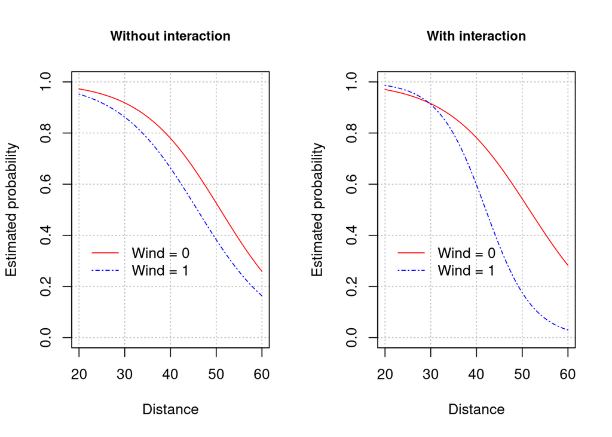

```r
    par(mfrow = c(1,2))

    curve(expr = predict(object = mod.fit.Ho, newdata = data.frame(distance = x, wind = 0), type = "response"), col = "red", lty = "solid", xlim = c(20,60),
          ylim = c(0,1), ylab = "Estimated probability", main = "Without interaction",
          xlab = "Distance", panel.first = grid(col = "gray", lty = "dotted"), cex.main = 0.9, lwd = 1)
    curve(expr = predict(object = mod.fit.Ho, newdata = data.frame(distance = x, wind = 1), type = "response"),
      col = "blue", lty = "dotdash", lwd = 1, add = TRUE)
    legend(x = 20, y = 0.4, legend = c("Wind = 0", "Wind = 1"), lty = c("solid", "dotdash"), col = c("red", "blue"),
      lwd = c(1,1), bty = "n")

    curve(expr = predict(object = mod.fit.Ha, newdata = data.frame(distance = x, wind = 0), type = "response"), col = "red", lty = "solid", xlim = c(20,60),
          ylim = c(0,1), ylab = "Estimated probability", main = "With interaction",
          xlab = "Distance", panel.first = grid(col = "gray", lty = "dotted"), cex.main = 0.9, lwd = 1)
    curve(expr = predict(object = mod.fit.Ha, newdata = data.frame(distance = x, wind = 1), type = "response"),
      col = "blue", lty = "dotdash", lwd = 1, add = TRUE)
    legend(x = 20, y = 0.4, legend = c("Wind = 0", "Wind = 1"), lty = c("solid", "dotdash"), col = c("red", "blue"),
      lwd = c(1,1), bty = "n")
```

Because of the interaction in the model, we need to interpret the effect of wind at specific levels of distance and vice-versa.

#### Odds ratio estimates and 95% Wald Confidence Intervals:

```r
beta.hat <- mod.fit.Ha$coefficients[2:4] #vector of the beta estimates
c <- 1 #doing c = 1 because we want to just interpret the effect of wind at different levels of distance. Since wind is a binary variable, how do the odds change including distance as an interaction variable?
distance <- seq(from = 20, to = 60, by = 10)

OR.wind <- exp(c*(beta.hat[2] + beta.hat[3]*distance))
cov.mat <- vcov(mod.fit.Ha)[2:4, 2:4]

#Var(beta-hat_2 + distance*beta-hat_3)
var.log.OR <- cov.mat[2,2] + distance^2*cov.mat[3,3] + 2*distance*cov.mat[2,3]

ci.log.OR.low <- c*(beta.hat[2] + beta.hat[3] * distance) - c*qnorm(p = 0.975)*sqrt(var.log.OR)
ci.log.OR.up <- c*(beta.hat[2] + beta.hat[3]*distance) + c*qnorm(p = 0.975) * sqrt(var.log.OR)

round(data.frame(distance = distance, OR.hat = 1/OR.wind, OR.low = 1/exp(ci.log.OR.up), OR.up = 1/exp(ci.log.OR.low)), 2)
```

```
##   distance OR.hat OR.low OR.up
## 1       20   0.45   0.09  2.34
## 2       30   1.04   0.40  2.71
## 3       40   2.41   1.14  5.08
## 4       50   5.57   1.54 20.06
## 5       60  12.86   1.67 99.13
```

```r
#We invert because a majority of the OR.wind results are under 1. We also exp() the CI cuz its part of the equation.
```

Odds increase with more sufficient evidence as distance increases. Intervals that do not include one indicate that wind does have an effect on the success or failure of a placekick at a distance.

**Odds ratio estimate with Profile LR:**

```r
install.packages('mcprofile')
library(package = mcprofile)
K <- matrix( data = c(0, 0, 1, 20,
                      0, 0, 1, 30,
                      0, 0, 1, 40,
                      0, 0, 1, 50,
                      0, 0, 1, 60), nrow = 5, ncol = 4, byrow = TRUE)
#K <- cbind(0, 0, 1, distance) # a quicker way to form K

linear.combo <- mcprofile(object = mod.fit.Ha, CM = K)
ci.log.OR <- confint(object = linear.combo, level = 0.95, adjust = 'none')

data.frame(distance, OR.hat = round(1/exp(ci.log.OR$estimate), 2), OR.low = round(1/exp(ci.log.OR$confint$upper),2), OR.up = round(1/exp(ci.log.OR$confint$lower), 2))
```

```
##    distance Estimate OR.low  OR.up
## C1       20     0.45   0.06   1.83
## C2       30     1.04   0.34   2.42
## C3       40     2.41   1.14   5.15
## C4       50     5.57   1.68  22.79
## C5       60    12.86   2.01 130.85
```

# Categorical Explanatory Variables

Let’s say you have a column that only has the values A, B, C, D. Then you can represent them as factors and convert the values to indicator variables.

$$\begin{align}
\large logit(\pi) = \beta_0 + \beta_1x_1 + \beta_2x_2 + \beta_3x_3
\end{align}$$

is the same as

$$\large logit(\pi) = \beta_0 + \beta_1B + \beta_2C + \beta_3D$$

A is included in the model when all the other indicator parameters are equal to 0.

Also, when we test for a column that’s been converted to a bunch of indicator variables, we have to set **every** indicator variable to 0 to test the column.

```r
tomato <- read.csv(file = './TomatoVirus.csv')
head(tomato)
```

```
##   Infest Control Plants Virus8
## 1      1       C    100     21
## 2      2       C    100     10
## 3      1       B    100     19
## 4      1       N    100     40
## 5      2       C    100     30
## 6      2       B    100     30
```

```r
tomato$Control <- as.factor(tomato$Control)
levels(tomato$Control)
```

```
## [1] "B" "C" "N"
```

```r
contrasts(tomato$Control)
```

```
##   C N
## B 0 0
## C 1 0
## N 0 1
```

```r
#Infest is numeric but still factor level. It doesn't matter since theres only 1 and 2, but if you had more you have to change it to factor class
contrasts(factor(tomato$Infest))
```

```
##   2
## 1 0
## 2 1
```

```r
tomato$Infest <- factor(tomato$Infest)
```

```r
mod.fit <- glm(formula = Virus8/Plants ~ Infest + Control, family = binomial(link = logit), data = tomato, weights = Plants)
summary(mod.fit)
```

```
##
## Call:
## glm(formula = Virus8/Plants ~ Infest + Control, family = binomial(link = logit),
##     data = tomato, weights = Plants)
##
## Deviance Residuals:
##    Min      1Q  Median      3Q     Max
## -4.288  -2.425  -1.467   1.828   8.379
##
## Coefficients:
##             Estimate Std. Error z value Pr(>|z|)
## (Intercept)  -0.6652     0.1018  -6.533 6.45e-11 ***
## Infest2       0.2196     0.1091   2.013   0.0441 *
## ControlC     -0.7933     0.1319  -6.014 1.81e-09 ***
## ControlN      0.5152     0.1313   3.923 8.74e-05 ***
## ---
## Signif. codes:  0 '***' 0.001 '**' 0.01 '*' 0.05 '.' 0.1 ' ' 1
##
## (Dispersion parameter for binomial family taken to be 1)
##
##     Null deviance: 278.69  on 15  degrees of freedom
## Residual deviance: 183.27  on 12  degrees of freedom
## AIC: 266.77
##
## Number of Fisher Scoring iterations: 4
```

The estimated logistic regression model is:

$$\large logit(\hat{\pi}) = -0.6652 + 0.2196Infest2 - 0.7933 ControlC+
0.5152ControlN$$

##### Interaction Variables

```r
#Model with interaction between Infest and Control
mod.fit.inter <- glm(formula = Virus8/Plants ~ Infest + Control + Infest:Control, family = binomial(link = logit), data = tomato, weights = Plants)
summary(mod.fit.inter)
```

```
##
## Call:
## glm(formula = Virus8/Plants ~ Infest + Control + Infest:Control,
##     family = binomial(link = logit), data = tomato, weights = Plants)
##
## Deviance Residuals:
##    Min      1Q  Median      3Q     Max
## -3.466  -2.705  -1.267   2.811   6.791
##
## Coefficients:
##                  Estimate Std. Error z value Pr(>|z|)
## (Intercept)       -1.0460     0.1316  -7.947 1.92e-15 ***
## Infest2            0.9258     0.1752   5.283 1.27e-07 ***
## ControlC          -0.1623     0.1901  -0.854    0.393
## ControlN           1.1260     0.1933   5.826 5.68e-09 ***
## Infest2:ControlC  -1.2114     0.2679  -4.521 6.15e-06 ***
## Infest2:ControlN  -1.1662     0.2662  -4.381 1.18e-05 ***
## ---
## Signif. codes:  0 '***' 0.001 '**' 0.01 '*' 0.05 '.' 0.1 ' ' 1
##
## (Dispersion parameter for binomial family taken to be 1)
##
##     Null deviance: 278.69  on 15  degrees of freedom
## Residual deviance: 155.05  on 10  degrees of freedom
## AIC: 242.55
##
## Number of Fisher Scoring iterations: 4
```

```r
#Testing all the interaction parameters
library(package = car)
Anova(mod.fit.inter)
```

```
## Analysis of Deviance Table (Type II tests)
##
## Response: Virus8/Plants
##                LR Chisq Df Pr(>Chisq)
## Infest            4.060  1     0.0439 *
## Control          91.584  2  < 2.2e-16 ***
## Infest:Control   28.224  2  7.434e-07 ***
## ---
## Signif. codes:  0 '***' 0.001 '**' 0.01 '*' 0.05 '.' 0.1 ' ' 1
```

The estimated logistic regression model is:

$$\large \begin{align}
logit(\hat{\pi}) = &-1.0460 + 0.9258Infest2 - 0.1623ControlC +
1.1260ControlN\\ &- 1.2114Infest2\times ControlC -
1.1662Infest2\times ControlN
\end{align}$$

Remember, Anova() is a LRT test we use. We used it in this case to test if there is an interaction between the infestation and control methods.

$$\large \begin{align}
H_0\::\:logit(\pi) = \begin{split}\beta_0 + \beta_1Infest2 +
\beta_2ControlC + \beta_3ControlN\end{split}\\
H_a\::\:logit(\pi) = \begin{split}\beta_0 + \beta_1Infest2 +
\beta_2ControlC + \beta_3ControlN \\+\beta_4Infest2 \times ControlC +
\beta_5Infest2 \times ControlN
\end{split}
\end{align}$$

### Odds Ratios for Indicator Variables

Model example:

$$\large logit(\pi) = \beta_0 + \beta_1x_1 + \beta_2x_2 + \beta_3x_1x_2$$

The odds of success at level B is exp($\large \beta_0 + \beta_1$) because x_1 = 1, x_2 = 0, and x_3 = 0.

Thus, the resulting odds ratio of comparing level B to level C is:

$$\large \frac{Odds_{x_1 = 1, x_2 = 0, x_3 = 0}}{Odds_{x_1 = 0, x_2 = 1,
x_3 = 0}} = \frac{exp(\beta_0 +\beta_1)}{exp(\beta_0+\beta_2)} =
exp(\beta_1 - \beta_2)$$

with a CI of:

$$\large exp\left(\hat{\beta_1}-\hat{\beta_2}\pm
Z_{1-a}\sqrt{\widehat{Var}(\hat{\beta}_1 - \hat{\beta}_2)}\right)$$

with Var:

$$\large \widehat{Var}(\hat{\beta}_1 - \hat{\beta}_2) =
\widehat{Var}(\hat{\beta}_1) +\widehat{Var}(\hat{\beta}_2) -
2\widehat{Cov}(\hat{\beta}_1, \hat{\beta}_2)$$

### Odds Ratios for Interaction Variables

Imagine X and Z are three level variables. Then, for example, the comparison of levels B and C of X at level B of Z is:

$$\large \frac{Odds_{x_1 = 1, x_2 = 0, z_1= 1, z_2 = 0}}{Odds_{x_1 = 0,
x_2 = 1, z_1= 1, z_2 = 0}} = \frac{exp(\beta_0 +\beta_1+\beta_3 +
\beta_5)}{exp(\beta_0+\beta_2+\beta_3 + \beta_7)} = exp(\beta_1 -
\beta_2+\beta_5 - \beta_7)$$

Where beta 5 and beta7 are interaction terms

```r
#Odds ratio of Control without interaction
exp(mod.fit$coefficients[3:4])
```

```
## ControlC ControlN
## 0.452342 1.674025
```

```r
#Control N vs. Control C
exp(mod.fit$coefficients[4] - mod.fit$coefficients[3])
```

```
## ControlN
## 3.700795
```

The odds ratio of no control vs biological control(base level) is 1.67. Inverted, we get 1/1.67 = 0.5973. This means that the estimated odds of using bio control vs no control is 0.59 times as large. This means that using the bio control reduces the odds of a plant showing symptoms by approximately 40%.

```r
#CI of odds comparing level N to level B
#Wald interval
exp(confint.default(object = mod.fit, parm = c("ControlC", "ControlN"), level = 0.95))
```

```
##              2.5 %    97.5 %
## ControlC 0.3492898 0.5857982
## ControlN 1.2941188 2.1654579
```

```r
#Profile likelihood ratio interval
exp(confint(object = mod.fit, parm = c("ControlC", "ControlN"), level = 0.95))
```

```
##              2.5 %    97.5 %
## ControlC 0.3486313 0.5848759
## ControlN 1.2945744 2.1666574
```

The odds of plants showing symptoms with no treatment is 1.29 to 2.17 times larger when compared to using a biological control. Alternatively, we can invert these numbers and say that the odds of plants showing symptoms are between 0.46 and 0.77 times as large when suing bio control rather than no control. Thus, the bio control reduces odds of a plant showing symptoms by approximately 23% to 54%.

```r
#Wald interval for Control N vs. Control C
beta.hat <- mod.fit$coefficients[-1] #Matches up beta indices. Basically getting rid of the first index in the coef vector. Really weird.
exp(beta.hat[3] - beta.hat[2])
```

```
## ControlN
## 3.700795
```

```r
cov.mat<- vcov(mod.fit)[2:4, 2:4]
var.N.C <- cov.mat[3,3] + cov.mat[2,2] - 2*cov.mat[3,2]
CI.betas <- beta.hat[3] - beta.hat[2] + qnorm(p = c(0.025, 0.975))* sqrt(var.N.C)

exp(CI.betas)
```

```
## [1] 2.800422 4.890649
```

### Odds ratio holding Infest2 constant

Comparing level N to level B

$$\large \frac{Odds_{ControlC= 0, ControlN = 1, Infest2= 0}}{Odds_{
ControlC= 0, ControlN = 0, Infest2= 0
}} = \frac{exp(\beta_0 +\beta_1+\beta_3 +
\beta_5)}{exp(\beta_0+\beta_1)} = exp(\beta_3+\beta_5)$$

```r
#Estimated OR for Control holding Infest2 constant
beta.hat <- mod.fit.inter$coefficients[-1]
N.B.Infest2.0 <- exp(beta.hat[3])
N.B.Infest2.1 <- exp(beta.hat[3] + beta.hat[5])
C.B.Infest2.1 <- exp(beta.hat[2])
C.B.Infest2.0 <- exp(beta.hat[2] +beta.hat[4])
N.C.Infest2.0 <- exp(beta.hat[3] - beta.hat[2])
N.C.Infest2.1 <- exp(beta.hat[3] - beta.hat[2] + beta.hat[5] - beta.hat[4])

comparison <- c("N vs. B", "N vs. B", "C vs. B", "C vs. B", "N vs. C", "N vs. C")
data.frame(Infest = c(0,1,0,1,0,1), Control = comparison, OR.hat = round(c(N.B.Infest2.0, N.B.Infest2.1, C.B.Infest2.0, C.B.Infest2.1, N.C.Infest2.0, N.C.Infest2.1),2))
```

```
##   Infest Control OR.hat
## 1      0 N vs. B   3.08
## 2      1 N vs. B   0.96
## 3      0 C vs. B   0.25
## 4      1 C vs. B   0.85
## 5      0 N vs. C   3.63
## 6      1 N vs. C   3.79
```

CI

```r
# Using mcprofile
    # library(package = mcprofile)  # If had not done yet
#Each row needed for odds ratio
    K<-matrix(data = c(0, 0,  0,  1,  0,  0,
                       0, 0,  0,  1,  0,  1,#comparing OR of level n to b with infest1
                       0, 0,  1,  0,  0,  0,
                       0, 0,  1,  0,  1,  0,
                       0, 0, -1,  1,  0,  0,
                       0, 0, -1,  1, -1,  1),  nrow = 6, ncol = 6, byrow = TRUE)
    linear.combo<-mcprofile(object = mod.fit.inter, CM = K)
    ci.log.OR<-confint(object = linear.combo, level = 0.95, adjust = "none")
    ci.log.OR
```

```
##
##    mcprofile - Confidence Intervals
##
## level:        0.95
## adjustment:   none
##
##    Estimate  lower  upper
## C1   1.1260  0.750  1.508
## C2  -0.0402 -0.400  0.318
## C3  -0.1623 -0.536  0.210
## C4  -1.3738 -1.750 -1.009
## C5   1.2884  0.905  1.678
## C6   1.3336  0.934  1.742
```

```r
    data.frame(Infest2 = c(0, 1, 0, 1, 0, 1), comparison, OR = round(exp(ci.log.OR$estimate),2),
       OR.CI = round(exp(ci.log.OR$confint),2))
```

```
##    Infest2 comparison Estimate OR.CI.lower OR.CI.upper
## C1       0    N vs. B     3.08        2.12        4.52
## C2       1    N vs. B     0.96        0.67        1.37
## C3       0    C vs. B     0.85        0.58        1.23
## C4       1    C vs. B     0.25        0.17        0.36
## C5       0    N vs. C     3.63        2.47        5.36
## C6       1    N vs. C     3.79        2.54        5.71
```

```r
#Wald way
    save.wald<-wald(object = linear.combo)
    ci.logit.wald<-confint(object = save.wald, level = 0.95, adjust = "none")
    data.frame(Infest2 = c(0, 1, 0, 1, 0, 1), comparison, OR = round(exp(ci.log.OR$estimate),2),
      lower = round(exp(ci.logit.wald$confint[,1]),2), upper = round(exp(ci.logit.wald$confint[,2]),2))
```

```
##    Infest2 comparison Estimate lower upper
## C1       0    N vs. B     3.08  2.11  4.50
## C2       1    N vs. B     0.96  0.67  1.38
## C3       0    C vs. B     0.85  0.59  1.23
## C4       1    C vs. B     0.25  0.17  0.37
## C5       0    N vs. C     3.63  2.46  5.34
## C6       1    N vs. C     3.79  2.53  5.68
```

Although remember, since we are doing all of these OR at once, we need to recognize the overall familywise confidence level. There are two ways to do this: bonferroni and single-step

```r
#Bonferroni
ci.log.bon <- confint(object = linear.combo, level = 0.95, adjust = 'bonferroni')

#Single Step
ci.log.ss <- confint(object = linear.combo, level = 0.95, adjust = 'single-step')
data.frame(Infest2 = c(0, 1, 0, 1,0, 1), comparison, bon = round(exp(ci.log.bon$confint), 2), ss = round(exp(ci.log.ss$confint),2))
```

```
##   Infest2 comparison bon.lower bon.upper ss.lower ss.upper
## 1       0    N vs. B      1.86      5.16     1.87     5.12
## 2       1    N vs. B      0.59      1.56     0.60     1.55
## 3       0    C vs. B      0.51      1.40     0.52     1.39
## 4       1    C vs. B      0.15      0.41     0.15     0.41
## 5       0    N vs. C      2.17      6.14     2.18     6.09
## 6       1    N vs. C      2.22      6.59     2.24     6.54
```

Both of these intervals allows us to claim that we are 95% confident that the process has covered ALL of the odds ratios, rather than merely having 95% confidence separately in each one. Same syntax for Wald

## Convergence of parameter estimation

glm() is used by itteratively changing the parameters until convergence is attained or until the maximum # of iterations is reached. Criteria used to determine convergence is change in residual deviance. Thus, if G^(k) is residual deviance at iteration k:

$$\large \frac{|G^{(k)} - G^{(k-1)}|}{0.1 + |G^{(k)}|} < \epsilon$$

You can pick your epsilon and maximum iterations in the procedure. Example:

```r
mod.fit <- glm(formula = good ~ distance, family = binomial(link = logit), data = placekick, trace = TRUE, epsilon = 0.0001, maxit = 50) #trace = TRUE shows the residual deviances per iteration)
```

```
## Deviance = 836.7715 Iterations - 1
## Deviance = 781.1072 Iterations - 2
## Deviance = 775.8357 Iterations - 3
## Deviance = 775.7451 Iterations - 4
## Deviance = 775.745 Iterations - 5
```

```r
mod.fit$control #convergence control values
```

```
## $epsilon
## [1] 1e-04
##
## $maxit
## [1] 50
##
## $trace
## [1] TRUE
```

Sample data set: x1 <=5 means y = 0. if x1 >5 then y = 1. Complete separation.

```r
set1 <- data.frame(x1 = c(1,2,3,4,5,6,7,8,9,10), y = c(0,0,0,0,0,1,1,1,1,1))
head(set1)
```

```
##   x1 y
## 1  1 0
## 2  2 0
## 3  3 0
## 4  4 0
## 5  5 0
## 6  6 1
```

This doesn’t work because the data is completely separated.

```r
mod.fit1 <- glm(formula = y ~ x1, data = set1, family = binomial(link = logit), trace = TRUE)
```

```
## Deviance = 4.270292 Iterations - 1
## Deviance = 2.574098 Iterations - 2
## Deviance = 1.577074 Iterations - 3
## Deviance = 0.8831108 Iterations - 4
## Deviance = 0.393253 Iterations - 5
## Deviance = 0.1446891 Iterations - 6
## Deviance = 0.05231577 Iterations - 7
## Deviance = 0.01909123 Iterations - 8
## Deviance = 0.007001166 Iterations - 9
## Deviance = 0.002572542 Iterations - 10
## Deviance = 0.000945971 Iterations - 11
## Deviance = 0.0003479471 Iterations - 12
## Deviance = 0.000127995 Iterations - 13
## Deviance = 4.708569e-05 Iterations - 14
## Deviance = 1.732172e-05 Iterations - 15
## Deviance = 6.372285e-06 Iterations - 16
## Deviance = 2.34423e-06 Iterations - 17
## Deviance = 8.623937e-07 Iterations - 18
## Deviance = 3.172569e-07 Iterations - 19
## Deviance = 1.167123e-07 Iterations - 20
## Deviance = 4.293612e-08 Iterations - 21
## Deviance = 1.579536e-08 Iterations - 22
## Deviance = 5.810837e-09 Iterations - 23
## Deviance = 2.137736e-09 Iterations - 24
## Deviance = 7.864775e-10 Iterations - 25
```

```r
mod.fit1$coefficients #last iteration parameters
```

```
## (Intercept)          x1
##  -245.84732    44.69951
```

There are two ways to deal with this.

1. Exact logistic regression
2. Modified likelihood function

we focus on 2.Basically:

$$\large \sum^n_{i = 1}(y_i - \pi_i + h_i(0.5 - \pi_i))x_{ir}$$

Where h is the ith diagonal element from the hat matrix, **H =** $V^{1/2}X(X'VX)X'V^{1/2}$. It is the penalty that ensures that the y^ith isnt always 0 or 1 and brings it closer.

This equation is basically the first derivative with respect to $\large \beta_r$. Also known as the modified score function since we set each derivative equal to 0 and solve for the parameter estimate from there.

```r
install.packages('logistf')
library(package = logistf)
mod.fit.firth1 <- logistf(formula = y ~ x1, data = set1)
options(digits = 4) #Controls printing in R Console window
summary(mod.fit.firth1)
```

```
## logistf(formula = y ~ x1, data = set1)
##
## Model fitted by Penalized ML
## Coefficients:
##                coef se(coef) lower 0.95 upper 0.95 Chisq        p method
## (Intercept) -5.3386   3.0309   -30.7818    -0.8313 6.374 0.011579      2
## x1           0.9706   0.5268     0.1962     5.5642 7.759 0.005345      2
##
## Method: 1-Wald, 2-Profile penalized log-likelihood, 3-None
##
## Likelihood ratio test=7.759 on 1 df, p=0.005345, n=10
## Wald test = 3.395 on 1 df, p = 0.06538
```

## Generalized Linear Models

Basically, logistic regression is taking the inverse CDF of a linear function.